# ECON 144 - Homework 2

Noah Kawasaki

4-24-18

## Packages

```r
library(tidyverse)
library(ggplot2)
library(reshape)
library(openxlsx)
library(readxl)
library(data.table)
library(tis)
library(zoo)
library(stats)
library(quantreg)
library(roll)
library(cowplot)
library(psych)

setwd("/Users/noahkawasaki/Desktop/ECON 144/Week 4")
```

## PROBLEM 1:

The data file labordata.dat consists of the labor force participation rates by gender (including the total, i.e., sum of male and female) for the years 1948-1991. Each observation is a monthly data point. The objective of this assignment is to fit a trend to the time series data, and based on the best fit model, make a 10 year forecast.

### Load data

```r
temp <- read_tsv('/Users/noahkawasaki/Desktop/ECON 144/Week 4/labordata.dat',
         col_names=c('both', 'female', 'male'))

# Manipulate
xmin <- parse_date('1948-01-01', format='%Y-%m-%d')
xmax <- parse_date('1990-12-31', format='%Y-%m-%d')

df <- temp %>%
  mutate(
    date=seq(from=xmin, to=xmax, by='month'),
    tseries=seq(0, 516, length=nrow(temp))  # Non datetime series for regression
  ) %>%
  dplyr::select(date, tseries, male, female, both)  # Re-order

attach(df)
```

#### (a) Show a time-series plot of your data. You can show all three variables on the same plot.

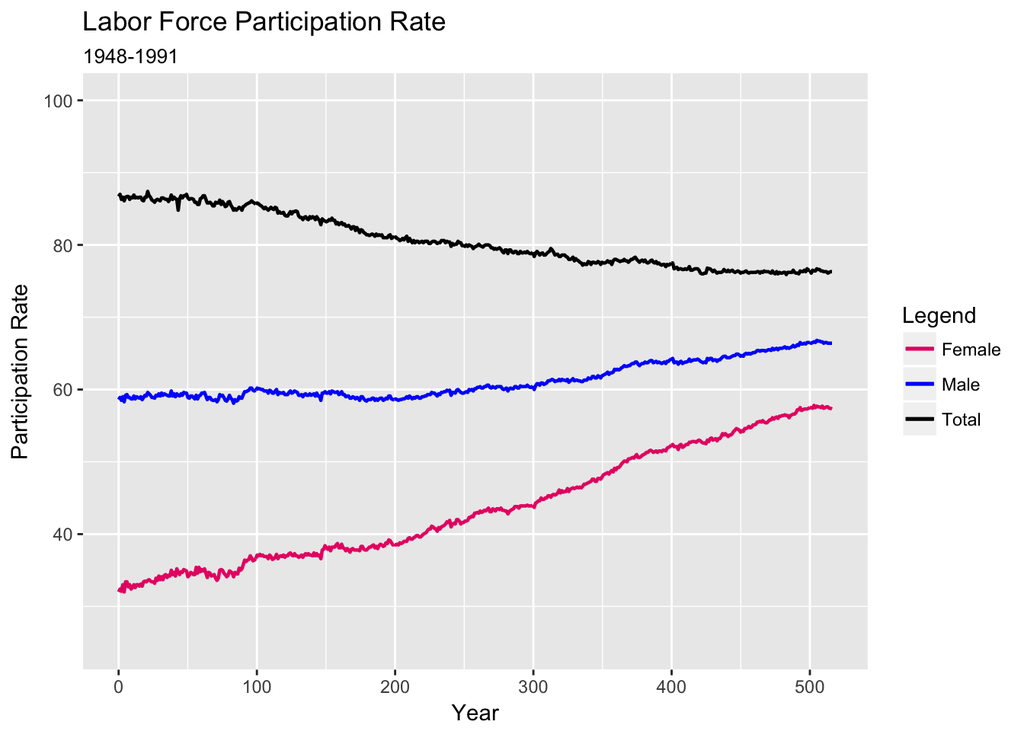

```r
cols1 <- c('Total'='black', 'Male'='blue', 'Female'='#E81072')
ggplot(df, aes(x=tseries)) +
  geom_line(aes(y=male, color='Male'), lwd=0.8) +
  geom_line(aes(y=female, color='Female'), lwd=0.8) +
  geom_line(aes(y=both, color='Total'), lwd=0.8) +
  ylim(25,100) +
  ggtitle('Labor Force Participation Rate ','1948-1991') +
  xlab('Year') +
  ylab('Participation Rate') +
  scale_fill_manual(name="Legend", values=cols1) +
  scale_color_manual(name="Legend", values=cols1) +
  theme_grey()
```

#### (b) Fit a linear, polynomial, and exponential model to the female labor force participation rate. For each model, plot the time series and overlay the respective fit. Discuss your results for each one.

##### Linear

```r
lr = lm(female~tseries)
summary(lr)
```

```
##
## Call:
## lm(formula = female ~ tseries)
##
## Residuals:
##     Min      1Q  Median      3Q     Max
## -2.3959 -1.1994  0.2523  1.0177  2.6321
##
## Coefficients:
##              Estimate Std. Error t value Pr(>|t|)
## (Intercept) 3.051e+01  1.104e-01   276.3   <2e-16 ***
## tseries     5.131e-02  3.704e-04   138.5   <2e-16 ***
## ---
## Signif. codes:  0 '***' 0.001 '**' 0.01 '*' 0.05 '.' 0.1 ' ' 1
##
## Residual standard error: 1.256 on 514 degrees of freedom
## Multiple R-squared:  0.9739, Adjusted R-squared:  0.9739
## F-statistic: 1.919e+04 on 1 and 514 DF,  p-value: < 2.2e-16
```

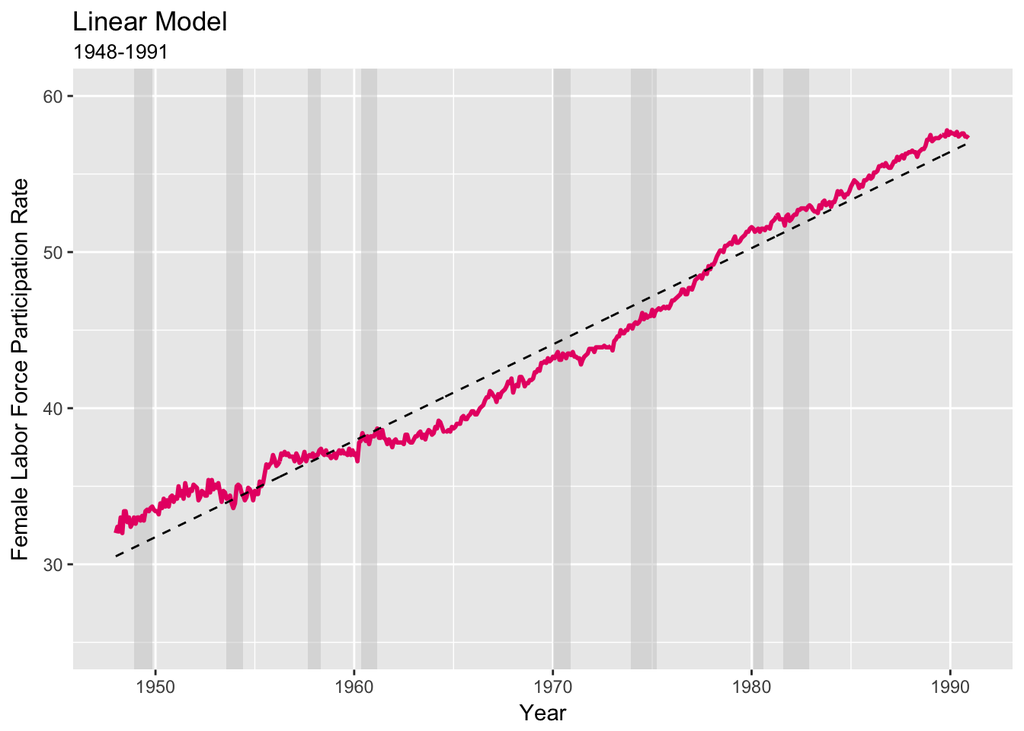

```r
nberShade(ggplot(data=df, aes(x=date))) +
  geom_line(aes(y=female), color='#E81072', lwd=1) +
  geom_line(aes(y=lr$fitted.values), color='black', linetype='dashed') +
  xlim(xmin, xmax) +
  ylim(25, 60) +
  ggtitle('Linear Model', '1948-1991') +
  xlab('Year') +
  ylab('Female Labor Force Participation Rate') +
  theme_grey()
```

We can see statistical significance in the time series for a linear model, and a high R<sup>2</sup> score of 0.97. The plot shows that a linear model does fit well on this particular series, but we can see some curviture in the values that might be better modeled.

##### Polynomial

```r
poly <- lm(female~tseries+I(tseries^2))
summary(poly)
```

```
##
## Call:
## lm(formula = female ~ tseries + I(tseries^2))
##
## Residuals:
##      Min       1Q   Median       3Q      Max
## -2.02400 -0.47184 -0.05572  0.42321  1.71762
##
## Coefficients:
##               Estimate Std. Error t value Pr(>|t|)
## (Intercept)  3.285e+01  9.013e-02  364.45   <2e-16 ***
## tseries      2.409e-02  8.068e-04   29.86   <2e-16 ***
## I(tseries^2) 5.275e-05  1.514e-06   34.85   <2e-16 ***
## ---
## Signif. codes:  0 '***' 0.001 '**' 0.01 '*' 0.05 '.' 0.1 ' ' 1
##
## Residual standard error: 0.6851 on 513 degrees of freedom
## Multiple R-squared:  0.9923, Adjusted R-squared:  0.9922
## F-statistic: 3.285e+04 on 2 and 513 DF,  p-value: < 2.2e-16
```

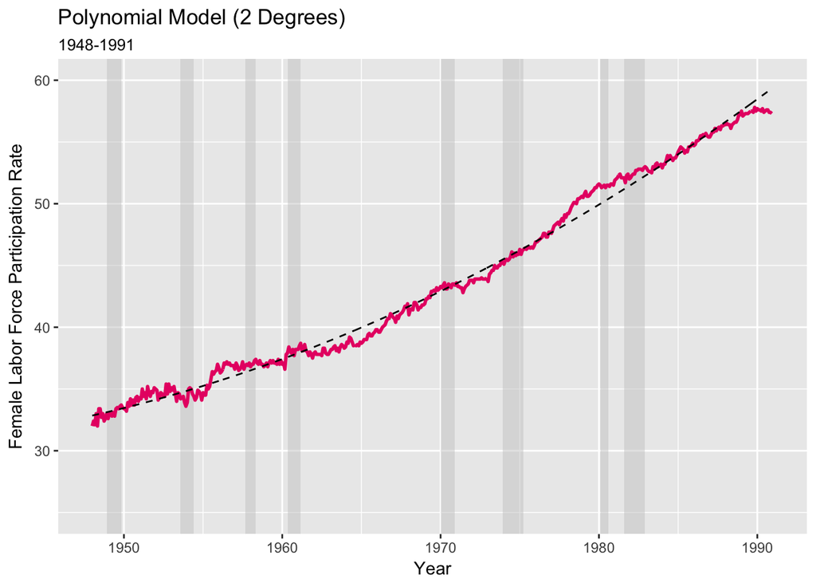

```r
nberShade(ggplot(data=df, aes(x=date))) +
  geom_line(aes(y=female), color='#E81072', lwd=1) +
  geom_line(aes(y=poly$fitted.values), color='black', linetype='dashed') +
  xlim(xmin, xmax) +
  ylim(25, 60) +
  ggtitle('Polynomial Model (2 Degrees)', '1948-1991') +
  xlab('Year') +
  ylab('Female Labor Force Participation Rate') +
  theme_grey()
```

For the polynomial model up to 2 degrees, we can see an improvement on the linear model. the R<sup>2</sup> score jumps up to 0.99, all parameters are statistically significant, and the fitted values look better fit on the plot.

##### Exponential

```r
er <- nls(female~exp(a+b*tseries), data=df, start=list(a=0, b=0))
er_fits <- predict(er, female)
er_resids <- resid(er)
summary(er)
```

```
##
## Formula: female ~ exp(a + b * tseries)
##
## Parameters:
##    Estimate Std. Error t value Pr(>|t|)
## a 3.455e+00  1.949e-03  1773.0   <2e-16 ***
## b 1.191e-03  5.707e-06   208.6   <2e-16 ***
## ---
## Signif. codes:  0 '***' 0.001 '**' 0.01 '*' 0.05 '.' 0.1 ' ' 1
##
## Residual standard error: 0.8282 on 514 degrees of freedom
##
## Number of iterations to convergence: 8
## Achieved convergence tolerance: 2.556e-07
```

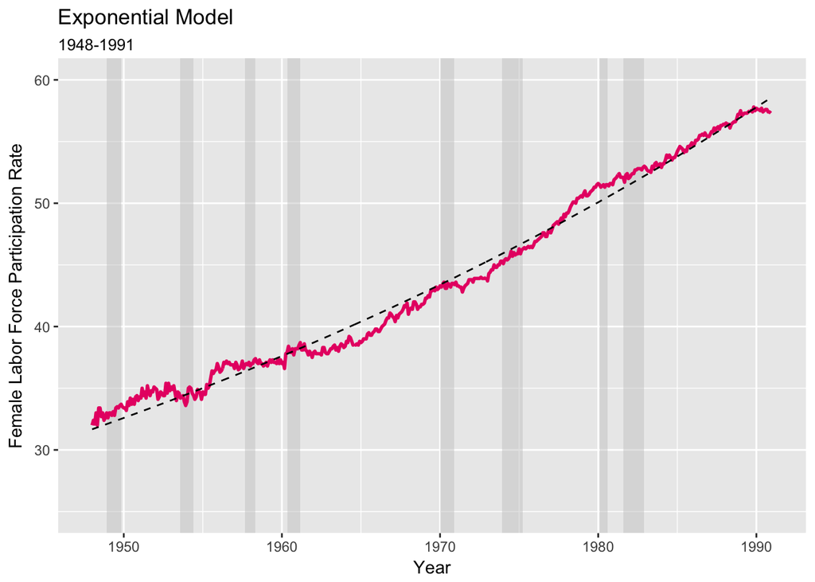

```r
nberShade(ggplot(data=df, aes(x=date))) +
  geom_line(aes(y=female), color='#E81072', lwd=1) +
  geom_line(aes(y=er_fits), color='black', linetype='dashed') +
  xlim(xmin, xmax) +
  ylim(25, 60) +
  ggtitle('Exponential Model', '1948-1991') +
  xlab('Year') +
  ylab('Female Labor Force Participation Rate') +
  theme_grey()
```

The exponential model looks very similar to the polynomial model. Both a and b are statistically significant, and visually we can see that it fits the series well.

#### (c) Plot the residuals vs. the fitted values for each model in the previous question. Discuss your results.

##### Linear

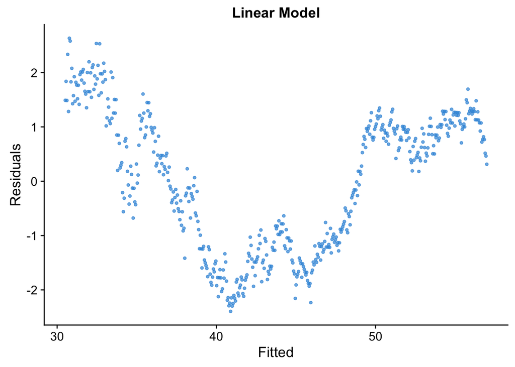

```r
ggplot(data=df, aes(x=lr$fitted.values, y=lr$residuals)) +
  geom_point(color='#3796db', alpha=0.7, lwd=1) +
  ggtitle('Linear Model') +
  xlab('Fitted') +
  ylab('Residuals')
```

##### Polynomial

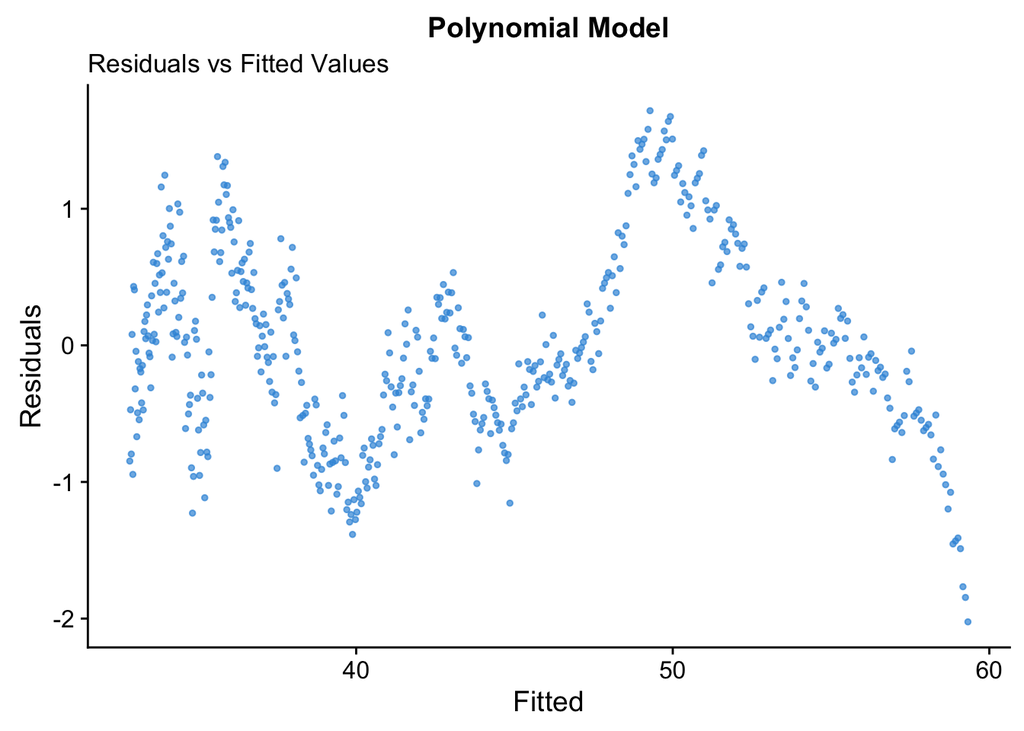

```r
ggplot(data=df, aes(x=poly$fitted.values, y=poly$residuals)) +
  geom_point(color='#3796db', alpha=0.7, lwd=1) +
  ggtitle('Polynomial Model', 'Residuals vs Fitted Values') +
  xlab('Fitted') +
  ylab('Residuals')
```

##### Exponential

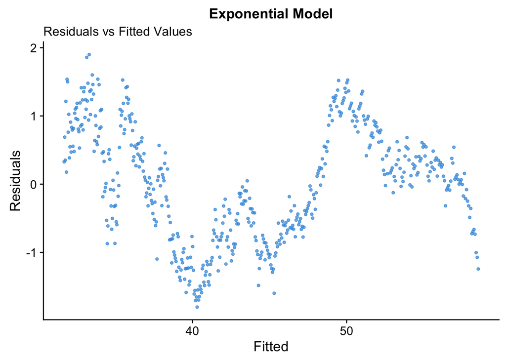

```r
ggplot(data=df, aes(x=er_fits, y=er_resids)) +
  geom_point(color='#3796db', alpha=0.7, lwd=1) +
  ggtitle('Exponential Model', 'Residuals vs Fitted Values') +
  xlab('Fitted') +
  ylab('Residuals')
```

From our residual plots, we clearly notice some structure. This suggests some cyclical components to the data that none of our models sufficiently captured. The polynomial residuals appear to have mean reversion and of the three, most likely to be covariance stationary.

#### (d) Based on AIC and BIC, choose the best fit model. Make sure to provide a table with the AIC and BIC computed values.

```r
AIC(lr, poly, er)
```

```
##      df      AIC
## lr    3 1703.462
## poly  4 1079.014
## er    3 1273.863
```

```r
BIC(lr, poly, er)
```

```
##      df      BIC
## lr    3 1716.201
## poly  4 1095.999
## er    3 1286.601
```

The polynomial model has the lower AIC and BIC scores, so I will continue the assignment with this model.

#### (e) Using your selected best fit model, forecast and plot your estimated female labor force participation rate for the years 1992-2002. Your forecast should include the 95% confidence and prediction intervals. Discuss your results.

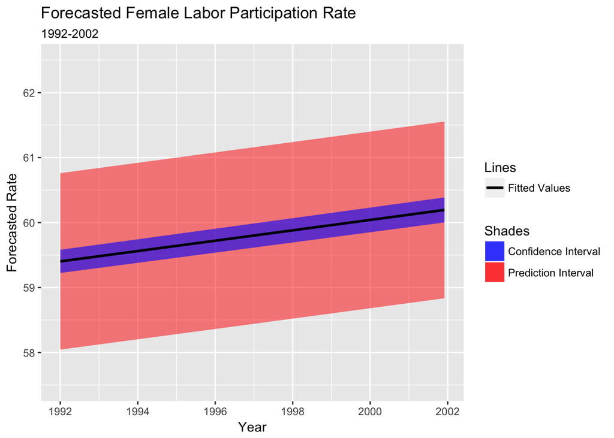

```r
# Simulated forcast horizon 1992-2002, * 12 for months
fh <- data.frame(tseries=seq(517, 527, length=120))
fxmin <- parse_date('1992-01-01', format='%Y-%m-%d')
fxmax <- parse_date('2001-12-31', format='%Y-%m-%d')
fh['date'] <- seq(from=fxmin, to=fxmax, by='month')

pred <- predict(poly, fh, se.fit=TRUE)

c_interval = as.data.frame(predict(poly, fh, level=0.95, interval="confidence"))
p_interval = as.data.frame(predict(poly, fh, level=0.95, interval="prediction"))

fh['pred'] <- pred$fit
fh['p_upr'] <- p_interval$upr
fh['p_lwr'] <- p_interval$lwr
fh['c_upr'] <- c_interval$upr
fh['c_lwr'] <- c_interval$lwr

cols2 <- c('Prediction Interval'='red', 'Confidence Interval'='blue', 'Fitted Values'='black')
ggplot(fh, aes(x=date)) +
  geom_ribbon(aes(ymin=p_lwr, ymax=p_upr, fill='Prediction Interval'), alpha=0.5) +
  geom_ribbon(aes(ymin=c_lwr, ymax=c_upr, fill='Confidence Interval'), alpha=0.6) +
  geom_line(aes(y=pred, color='Fitted Values'), lwd=1) +
  ylim(57.5, 62.5) +
  ggtitle('Forecasted Female Labor Participation Rate', '1992-2002') +
  xlab('Year') +
  ylab('Forecasted Rate') +
  scale_fill_manual(name="Shades", values=cols2) +
  scale_color_manual(name="Lines", values=cols2) +
  theme_grey()
```

For 1992-2002, our model predicted values in the range from 59 to 61, in a linear fashion. We can see visually that the 95% confidence interval follows the same linear pattern, and the prediction interval as well with a wider margin.

#### (f) Fit a Holt-Winters filter to your data and show the fit. How does this model compare to your best fit model?

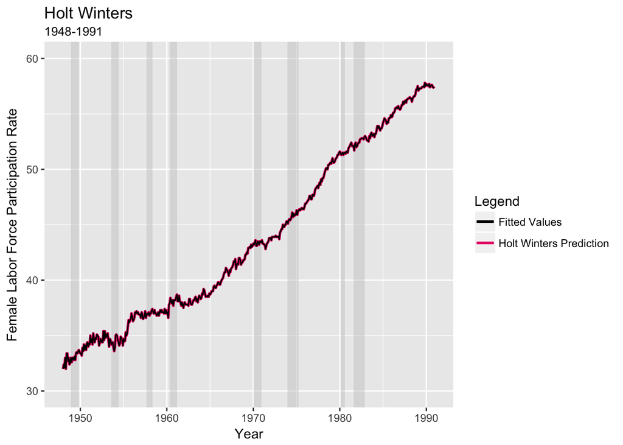

```r
female_ts <- ts(female, start=1948, frequency=12)
hw = HoltWinters(female_ts)

cols3 <- c('Fitted Values'='black', 'Holt Winters Prediction'='#E81072')
nberShade(ggplot(data=df, aes(x=date))) +
  geom_line(aes(y=female, color='Holt Winters Prediction'), lwd=1) +
  geom_line(aes(y=hw$x, color='Fitted Values')) +
  xlim(xmin, xmax) +
  ylim(30, 60) +
  ggtitle('Holt Winters', '1948-1991') +
  xlab('Year') +
  ylab('Female Labor Force Participation Rate') +
  scale_color_manual(name='Legend', values=cols3) +
  theme_grey()
```

#### (g) Based on the Holt-Winters fit, forecast and plot your estimated female labor force participation rate for the years 1992-2002. Your forecast should include the error bands. Discuss your results.

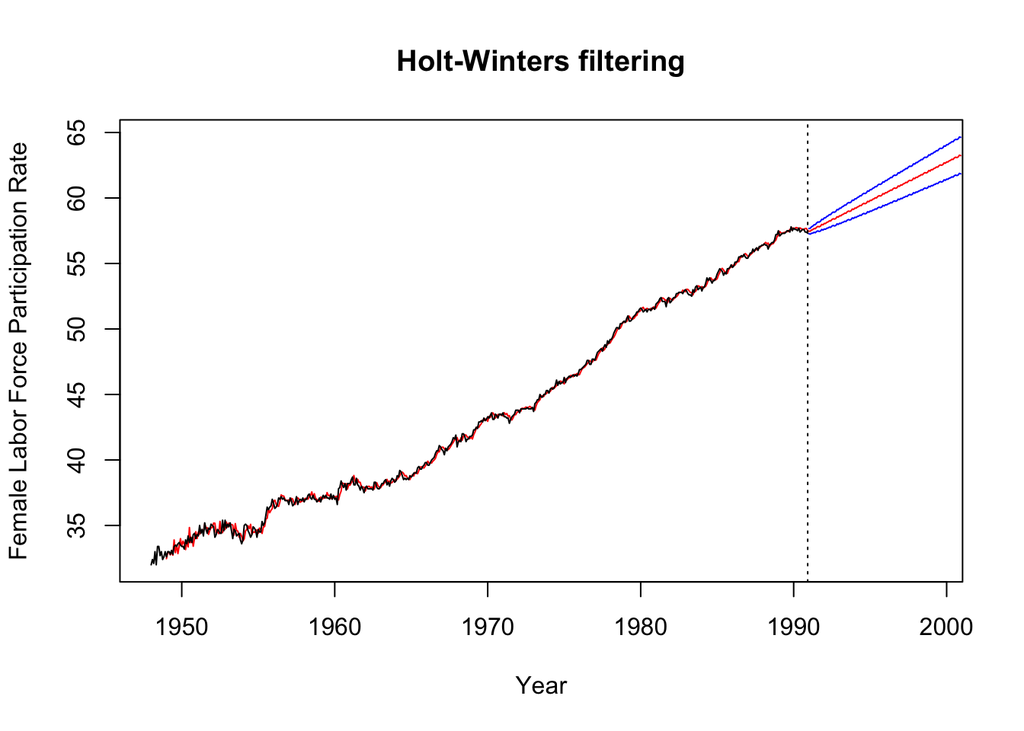

```r
fh['hw_pred'] <- predict(hw, 120, prediction.interval=TRUE, level=0.5)

plot(hw, fh$hw_pred, ylab="Female Labor Force Participation Rate", xlab="Year", xlim=c(1948,1999))
```

## TEXTBOOK PROBLEMS

```r
setwd("/Users/noahkawasaki/Desktop/ECON 144/Textbook_data")
```

### PROBLEM 3.2

```r
df32_temp <- read.xlsx("Chapter3_exercises_data.xlsx", sheet=2, detectDates=TRUE)
df32 <- df32_temp %>%
  mutate(
    inflation=log(cpi)-log(lag(cpi)),
    nomrate_monthly=(100*(((1+(nomrate/100))^(1/12))-1)),
    ex_post_real=nomrate_monthly-inflation
  )

# 3.1 Data
df31_temp <- read.xlsx("Chapter3_exercises_data.xlsx", sheet=1, detectDates=TRUE)[,1:3]
df31 <- df31_temp %>%
  mutate(
    rpce_growth=log(rpce)-log(lag(rpce)),
    rdpi_growth=log(rdpi)-log(lag(rdpi))
  )

# Join
join <- merge(df32, df31, by='date')

lr_join <- lm(rpce_growth~rdpi_growth+ex_post_real, data=join)
summary(lr_join)
```

```
##
## Call:
## lm(formula = rpce_growth ~ rdpi_growth + ex_post_real, data = join)
##
## Residuals:
##        Min         1Q     Median         3Q        Max
## -0.0303760 -0.0029999  0.0001516  0.0031385  0.0242341
##
## Coefficients:
##                Estimate Std. Error t value Pr(>|t|)
## (Intercept)   0.0026505  0.0004314   6.144 1.42e-09 ***
## rdpi_growth   0.1747101  0.0291984   5.984 3.65e-09 ***
## ex_post_real -0.0009758  0.0009079  -1.075    0.283
## ---
## Signif. codes:  0 '***' 0.001 '**' 0.01 '*' 0.05 '.' 0.1 ' ' 1
##
## Residual standard error: 0.005317 on 636 degrees of freedom
##   (1 observation deleted due to missingness)
## Multiple R-squared:  0.05481,    Adjusted R-squared:  0.05184
## F-statistic: 18.44 on 2 and 636 DF,  p-value: 1.641e-08
```

When we add the real interest rate as a predictor for consumption rate growth, we can see that it is statistically insignificant. This means that real interest rate is not necessarily associated with consumption behaviors.

### PROBLEM 4.4

##### Load data

```r
annual_temp <- read_excel("Chapter4_exercises_data.xls", sheet=1)
setnames(annual_temp, c('year', 'price', 'interest'))

quarterly_temp <- read_excel("Chapter4_exercises_data.xls", sheet=2)
setnames(quarterly_temp, c('quarter', 'price', 'interest'))

# Set up dataframes
annual <- annual_temp %>%
  mutate(
    price_growth=log(price)-log(lag(price)),
    interest_growth=log(interest)-log(lag(interest)),
    price_growth_lag1=lag(price_growth, 1),
    price_growth_lag2=lag(price_growth, 2),
    price_growth_lag3=lag(price_growth, 3),
    price_growth_lag4=lag(price_growth, 4)
  )

quarterly <- quarterly_temp %>%
  mutate(
    price_growth=log(price)-log(lag(price)),
    interest_growth=log(interest)-log(lag(interest)),
    price_growth_lag1=lag(price_growth, 1),
    price_growth_lag2=lag(price_growth, 2),
    price_growth_lag3=lag(price_growth, 3),
    price_growth_lag4=lag(price_growth, 4)
  )
```

##### Annual Models

```r
lr44a_1 <- lm(price_growth~price_growth_lag1, data=annual)
lr44a_2 <- lm(price_growth~price_growth_lag1+price_growth_lag2, data=annual)
lr44a_3 <- lm(price_growth~price_growth_lag1+price_growth_lag2+price_growth_lag3, data=annual)
lr44a_4 <- lm(price_growth~price_growth_lag1+price_growth_lag2+price_growth_lag3+price_growth_lag4, data=annual)
```

```r
AIC(lr44a_1, lr44a_2, lr44a_3, lr44a_4)
```

```
##         df       AIC
## lr44a_1  3 -144.2630
## lr44a_2  4 -147.9981
## lr44a_3  5 -141.8039
## lr44a_4  6 -134.6047
```

```r
BIC(lr44a_1, lr44a_2, lr44a_3, lr44a_4)
```

```
##         df       BIC
## lr44a_1  3 -139.5969
## lr44a_2  4 -141.8926
## lr44a_3  5 -134.3214
## lr44a_4  6 -125.8103
```

For the models at the annual frequency, we observe the lowest AIC and BIC scores for the model with up to two lag periods.

##### Quarterly Models

```r
lr44q_1 <- lm(price_growth~price_growth_lag1, data=quarterly)
lr44q_2 <- lm(price_growth~price_growth_lag1+price_growth_lag2, data=quarterly)
lr44q_3 <- lm(price_growth~price_growth_lag1+price_growth_lag2+price_growth_lag3, data=quarterly)
lr44q_4 <- lm(price_growth~price_growth_lag1+price_growth_lag2+price_growth_lag3+price_growth_lag4, data=quarterly)
```

```r
AIC(lr44q_1, lr44q_2, lr44q_3, lr44q_4)
```

```
##         df       AIC
## lr44q_1  3 -734.7684
## lr44q_2  4 -729.6127
## lr44q_3  5 -812.3312
## lr44q_4  6 -805.9869
```

```r
BIC(lr44q_1, lr44q_2, lr44q_3, lr44q_4)
```

```
##         df       BIC
## lr44q_1  3 -726.3076
## lr44q_2  4 -718.3639
## lr44q_3  5 -798.3111
## lr44q_4  6 -789.2122
```

For the models at the quarterly frequency, we observe the lowest AIC and BIC with up to three lag periods. Intuitively, this makes sense compared to the annual, as the time periods are closer together quarter to quarter and we would expect more importance in additional lag parameters. I will use the lrrq_3 model for the rest of the problem.

##### Recursive Model

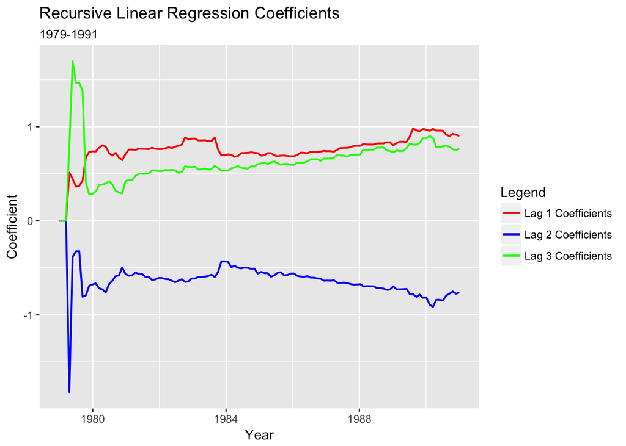

```r
X <- as.matrix(na.omit(quarterly[c('price_growth', 'price_growth_lag1', 'price_growth_lag2', 'price_growth_lag3')]))
explanatories <- X[,2:4]
target <- as.matrix(X[,1])

rec_model <- quantreg::lm.fit.recursive(X=explanatories, y=target)

lag1_rec_coeffs <- rec_model[2,]
lag2_rec_coeffs <- rec_model[3,]
lag3_rec_coeffs <- rec_model[4,]
rec_date_vector <- seq(from=1979, to=1991, length=length(rec_model[1,]))
rec_df <- data.frame(rec_date_vector, lag1_rec_coeffs, lag2_rec_coeffs, lag3_rec_coeffs)

cols4 <- c("Lag 1 Coefficients"="red","Lag 2 Coefficients"="blue","Lag 3 Coefficients"="green")
ggplot(data=rec_df, aes(x=rec_date_vector)) +
  geom_line(aes(y=lag1_rec_coeffs, color='Lag 1 Coefficients'), lwd=0.7, na.rm=TRUE) +
  geom_line(aes(y=lag2_rec_coeffs, color='Lag 2 Coefficients'), lwd=0.7, na.rm=TRUE) +
  geom_line(aes(y=lag3_rec_coeffs, color='Lag 3 Coefficients'), lwd=0.7, na.rm=TRUE) +
  ggtitle('Recursive Linear Regression Coefficients', '1979-1991') +
  ylab('Coefficient') +
  xlab('Year') +
  scale_color_manual(name="Legend", values=cols4) +
  theme_gray()
```

With the recursive model, we can see higher volatility in the beginning and smaller, constant changes further on. This would be expected because in earlier time periods, each coefficient value will have more weight. The parameter coefficients then converge to their estimates with the full data sample. Note that after about 1984, the changes in coefficients is quite smooth.

##### Rolling Coefficients

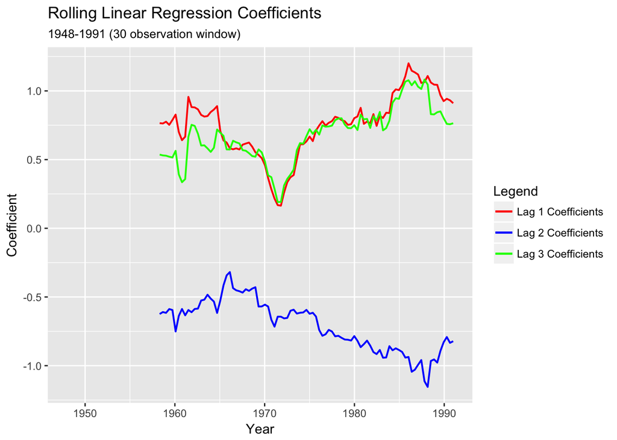

```r
rollover <- roll_lm(x=explanatories, y=target, width=30)

lag1_roll_coeffs <- rollover$coefficients[,2]
lag2_roll_coeffs <- rollover$coefficients[,3]
lag3_roll_coeffs <- rollover$coefficients[,4]
roll_date_vector <- seq(from=1948, to=1991, length=length(rec_model[1,]))
roll_df <- data.frame(roll_date_vector, lag1_roll_coeffs, lag2_roll_coeffs, lag3_roll_coeffs)

ggplot(data=roll_df, aes(x=roll_date_vector)) +
  geom_line(aes(y=lag1_roll_coeffs, color='Lag 1 Coefficients'), lwd=0.7, na.rm=TRUE) +
  geom_line(aes(y=lag2_roll_coeffs, color='Lag 2 Coefficients'), lwd=0.7, na.rm=TRUE) +
  geom_line(aes(y=lag3_roll_coeffs, color='Lag 3 Coefficients'), lwd=0.7, na.rm=TRUE) +
  ggtitle('Rolling Linear Regression Coefficients', '1948-1991 (30 observation window)') +
  ylab('Coefficient') +
  xlab('Year') +
  scale_fill_manual(name="Legend", values=cols4) +
  scale_color_manual(name="Legend", values=cols4) +
  theme_gray()
```

## PROBLEM 4.6

##### Set up dataframe

```r
greenbook_temp <- read_excel("Chapter4_exercises_data.xls", sheet=3)
setnames(greenbook_temp, c('date', 'actual_growth', 'forecasted_growth'))

# Set up dataframe
greenbook <- greenbook_temp %>%
  mutate(
    date=as.Date(as.yearqtr(greenbook_temp$date, format="%Y:Q%q")),
    forecast_errors=actual_growth-forecasted_growth
  )
```

##### Plots

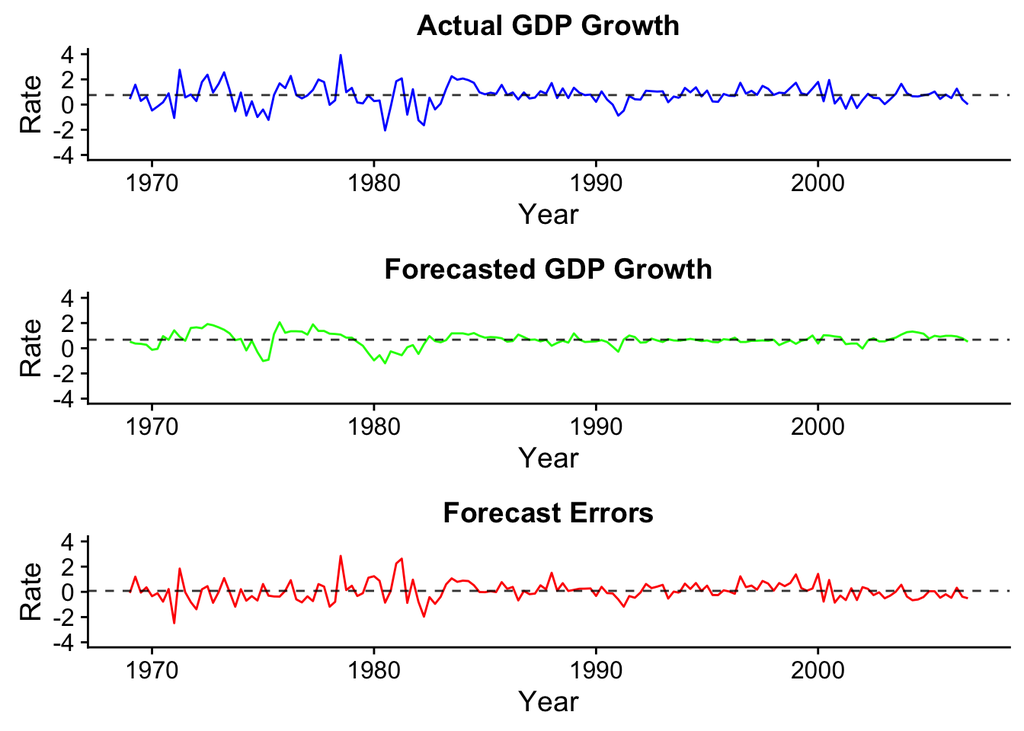

```r
p1 <- ggplot(greenbook, aes(x=date)) +
  geom_line(aes(y=actual_growth), color='blue') +
  geom_hline(yintercept=mean(greenbook$actual_growth), linetype='dashed', color='black', alpha=0.8) +
  ylim(-4, 4) +
  ggtitle('Actual GDP Growth') +
  xlab('Year') +
  ylab('Rate')

p2 <- ggplot(greenbook, aes(x=date)) +
  geom_line(aes(y=forecasted_growth), color='green') +
  geom_hline(yintercept=mean(greenbook$forecasted_growth), linetype='dashed', color='black', alpha=0.8) +
  ylim(-4, 4) +
  ggtitle('Forecasted GDP Growth') +
  xlab('Year') +
  ylab('Rate')

p3 <- ggplot(greenbook, aes(x=date)) +
  geom_line(aes(y=forecast_errors), color='red') +
  geom_hline(yintercept=mean(greenbook$forecast_errors), linetype='dashed', color='black', alpha=0.8) +
  ylim(-4, 4) +
  ggtitle('Forecast Errors') +
  xlab('Year') +
  ylab('Rate')

plot_grid(p1, p2, p3, ncol=1)
```

The time series plots show that all exhibit mean reversion, but no constant variances. There is also higher clusters of volatility in each plot before around 1983, and then calmer levels later on. The series all appear exhibit qualities of first order covariance stationarity.

##### Descriptive statistics

```r
psych::describe(greenbook, na.rm=TRUE)
```

```
##                   vars   n mean   sd median trimmed  mad   min  max range
## date                 1 152  NaN   NA     NA     NaN   NA   Inf -Inf  -Inf
## actual_growth        2 152 0.75 0.84   0.77    0.77 0.63 -2.05 3.93  5.98
## forecasted_growth    3 152 0.68 0.55   0.67    0.71 0.40 -1.20 2.06  3.26
## forecast_errors      4 152 0.08 0.75   0.05    0.05 0.64 -2.48 2.85  5.33
##                    skew kurtosis   se
## date                 NA       NA   NA
## actual_growth     -0.10     1.66 0.07
## forecasted_growth -0.64     1.47 0.04
## forecast_errors    0.43     2.07 0.06
```

On average, GDP growth rate is positive at 0.75%, and the forecasted growth rates were underpredicted in general, with a 0.68% mean. The actual growth rates also had higher deviations and a higher range of values than the forecasted growth rates. Another way to put this is that the forecasts were less volatile than the actual values.

##### ACF and PACFs

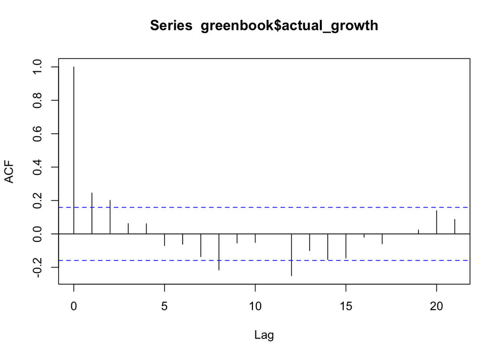

```r
acf(greenbook$actual_growth)
```

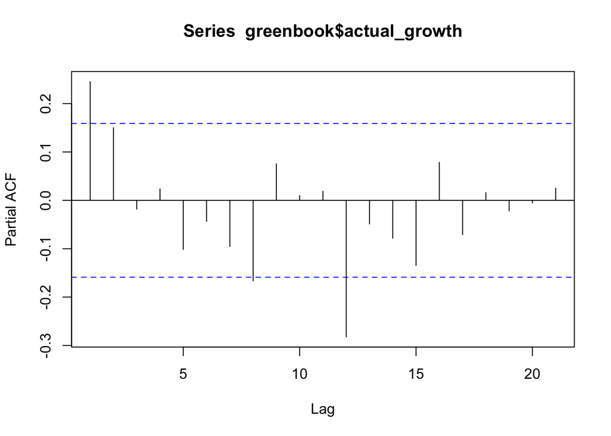

```r
pacf(greenbook$actual_growth)
```

The actual price growth plots tell us that there may be some time dependence on the last two quarters, but not further past that.

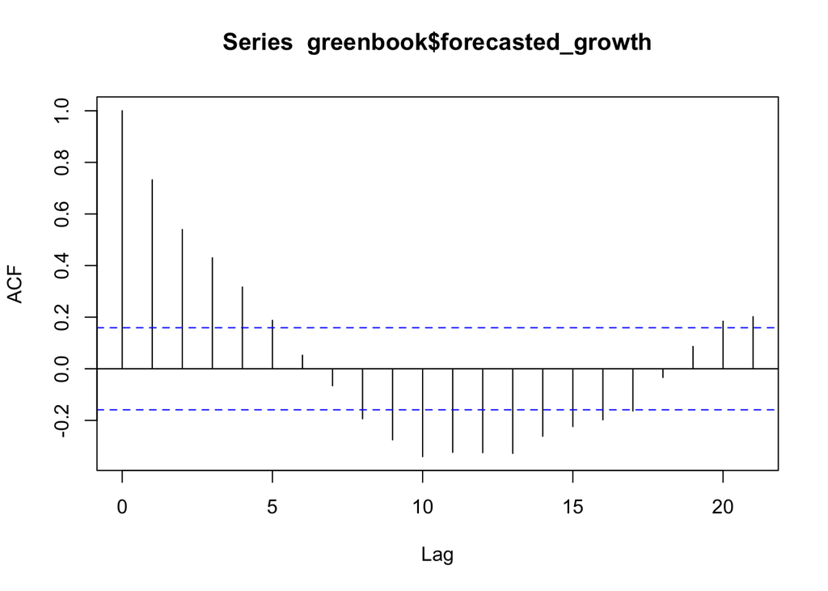

```r
acf(greenbook$forecasted_growth)
```

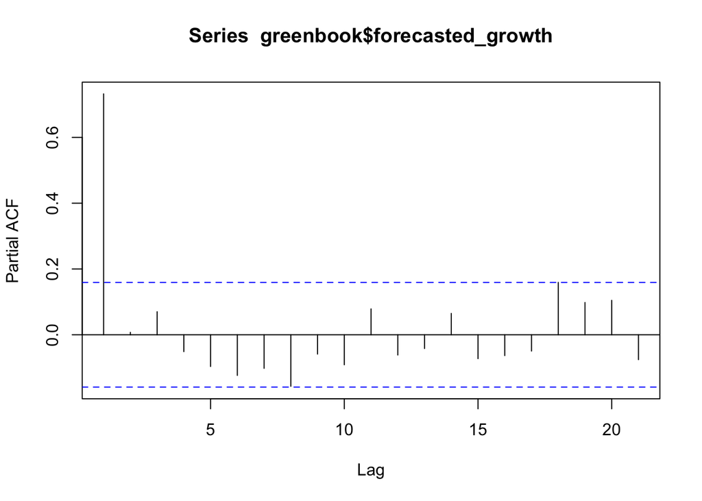

```r
pacf(greenbook$forecasted_growth)
```

The forecasted growth rate plots have similar *overall* characteristics to the actual growth rates, but more defined shapes. We can see the oscillating nature more clearly than in the actual data. This is because forecast profiles exhibits more time depenency, as it does not encapsulate the unpredictable nature or shocks that occur in reality.

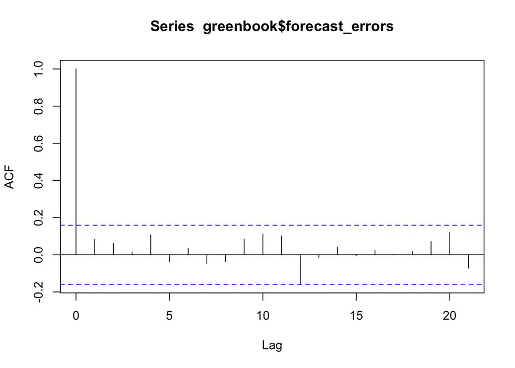

```r
acf(greenbook$forecast_errors)
```

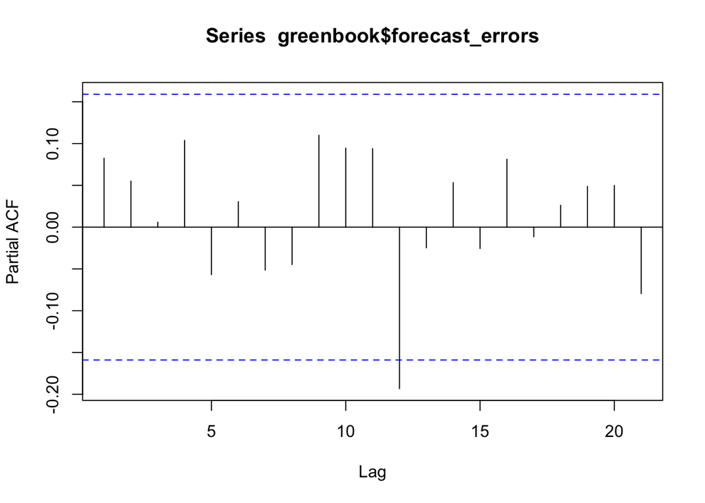

```r
pacf(greenbook$forecast_errors)
```

## PROBLEM 5.4

##### Data

```r
amex_temp <- read_xlsx("Chapter5_exercises_data.xlsx", sheet=3)[,1:2]
setnames(amex_temp, c('date', 'price'))

amex <- amex_temp %>%
  mutate(
    return=log(price)-log(lag(price))
  )

sp500_temp <- read_xlsx("Chapter5_exercises_data.xlsx", sheet=3)[,4:5]
setnames(sp500_temp, c('date', 'price'))

sp500 <- sp500_temp %>%
  mutate(
    return=log(price)-log(lag(price))
  )
```

##### AMEX

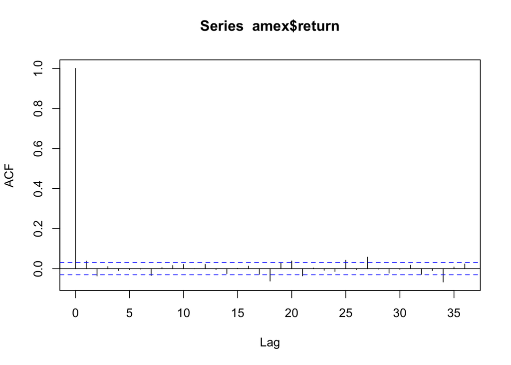

```r
acf(amex$return, na.action=na.omit)
```

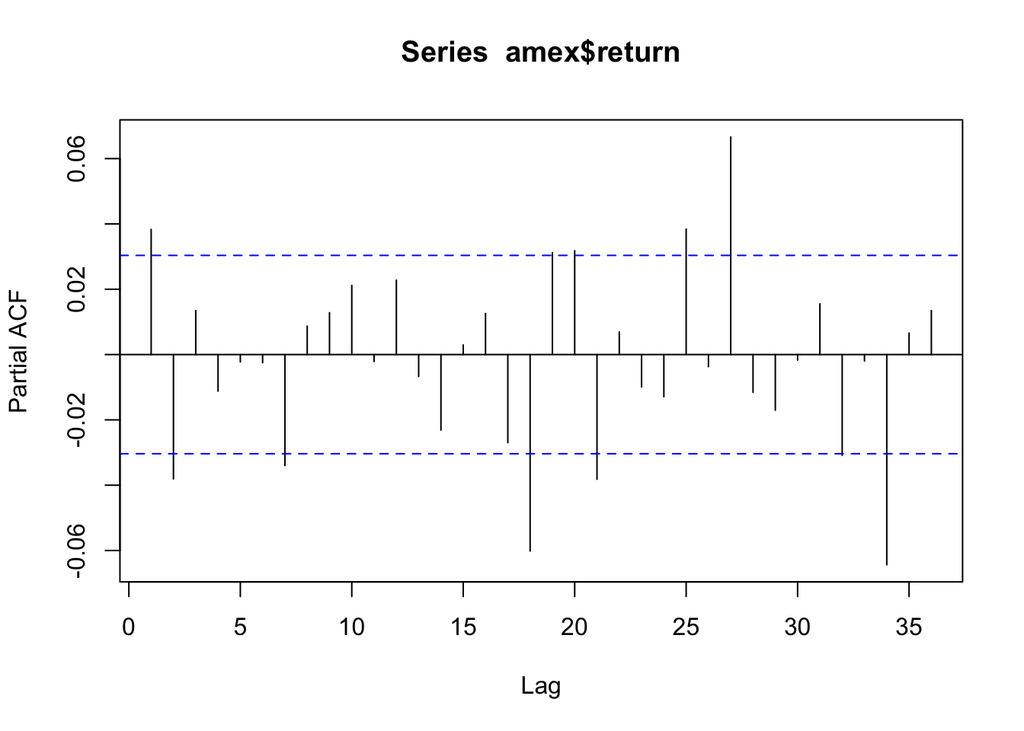

```r
pacf(amex$return, na.action=na.omit)
```

The AMEX updateed correlograms look very similar to the textbook correlograms. The autocorrelations are very low, or pretty much zero. Note that although some spikes are above the confidence interval, they do not carry meaning. The first order autocorrelation is also smaller than the textbooks. This means that the nontrading probability is very low in respect to models of non-synchronous trading.

##### S&P 500

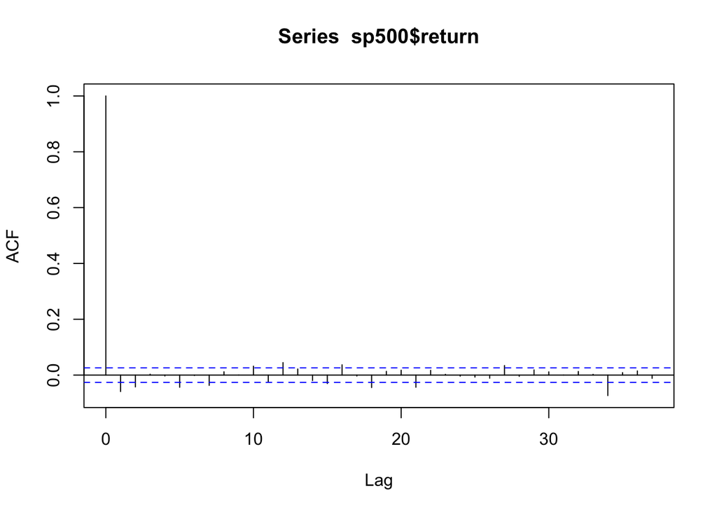

```r
acf(sp500$return, na.action=na.omit)
```

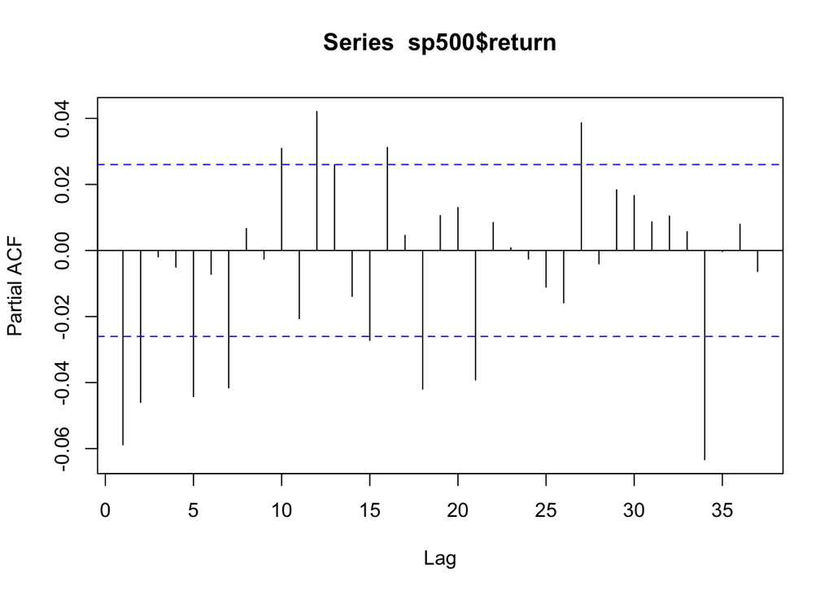

```r
pacf(sp500$return, na.action=na.omit)
```

The S&P 500 correlograms exhibit similar qualities as AMEX. Since there is a higher trading frequency for larger companies, the S&P 500 autocorrelations are expected to be zero, as they mostly trade daily.